# seminario401

Andrés Felipe Palomino

2023-08-30

## Estimación puntual y por intervalos de confianza

Para esta sección trabajaremos con la base de datos *ais* de la librería *alr4* del software estadístico R.Esta base de datos cuenta con un registro de 102 hombres y 100 mujeres atletas que pertenecen a un instituto de deporte en Australia. Se cuenta con un total de 14 variables.

El rendimiento deportivo de los atletas puede verse influenciado por diferentes factores, unos de estos pueden ser su género, deporte prácticado, etc. Este mismos se reflejan en diferentes tipos de variables que se ilustraran a continuación.

## Importación de la base de datos

```r
library(alr4) #Librería a trabajar
X<- ais #Baja de base de datos
```

Inicialmente realizaremos definiremos cada variable:

1. Sex: Sexo de los atletas 0 si es hombre 1 si es mujer.(Cualitativa)
2. Ht:Estatura en cm. (Cuantitativa)
3. Wt: Peso en kilogramos. (Cuantitativa)
4. LBM: Masa corporal magra. (Cuantitativa)
5. RCC: Recuento de globulos rojos . (Cuantitativa)
6. WCC: Recuento de globulos blancos . (Cuantitativa)
7. Hc: Hematrocitos . (Cuantitativa)
8. Hg: Hemoglobina . (Cuantitativa)
9. Ferr: Concentración de ferritina en el plasma (Cuantitativa)
10. BMI: Indíce de masa corporal . (Cuantitativa)
11. SSF: Suma de pliegues en la piel . (Cuantitativa)
12. Bfat: Porcentaje de grasa corporal . (Cuantitativa)
13. Label: Categoría . (Cualitativa)
14. Sport: Deporte . (Cualitativa)

Nos centraremos en analizar los comportamientos a nivel de estructura corporal relacionados con el peso y el género de estos deportistas.Por este motivo a pesar de contar con una gran cantidad de variables para acotar nuestro estudio seleccionaremos únicamente las variables Sex, LBM,BMI, SSF, Bfat. Puesto que son aquellas que nos describen las estructuras mencionadas inicialmente.

Después de este contexto procederemos a definir que es la estimación puntual y por intervalos: ## Estimación puntual: La estimación puntual es un concepto estadístico que se refiere a la estimación de un parámetro poblacional específico utilizando información de una muestra de datos. En otras palabras, consiste en calcular un único valor que se considera como la mejor aproximación del valor real del parámetro que se está tratando de estimar en una población.

Por ejemplo, si estás tratando de estimar la media de altura de una población de personas, puedes tomar una muestra aleatoria de individuos y calcular la media de altura de esa muestra. La media de altura calculada a partir de la muestra se conoce como la estimación puntual de la media de altura en la población.

Es importante tener en cuenta que la estimación puntual no proporciona información sobre la variabilidad o la incertidumbre asociada con la estimación. Para abordar esta incertidumbre, es común acompañar la estimación puntual con un intervalo de confianza, que proporciona un rango de valores dentro del cual es probable que se encuentre el parámetro poblacional con cierto nivel de confianza.

En resumen, la estimación puntual es el cálculo de un único valor que representa la mejor conjetura o aproximación del valor de un parámetro poblacional a partir de una muestra de datos.

Las formúlas para las estimaciónes puntuales para los párametros mas cómunes(media, varianza y proporción respectivamente) son las siguientes:

$$\bar{x}=\frac{\sum_{i=1}^n{x_i}}{n}$$
$$s^2=\frac{\sum_{i=1}^n{(x_i-\bar{x})^2}}{n-1}$$
$$\hat{p}=\frac{x}{n}$$
Siendo un proceso análogo para las estimaciones por diferencias para cada grupo independiente. Por TLC, se demuestra que asintóticamente el estimador de la media muestral converge a una distribución normal, es decir:
$$\bar{x} \rightarrow Normal( \mu,
\frac{\sigma}{\sqrt{n}})$$
Dónde cuando asusimos un tamaño de muestra mayor a 30 obtenemos que:
$$\sigma\approx S$$
Un poco de esta ilustración podemos verla en el siguiente código:

Obtendremos muestras de tamaño 100 de una distribución exponencial con párametro 1, posterior a eso ilustraremos la media de mil veces este experimento y observamos que asintóticamente se comporta como una distribución normal

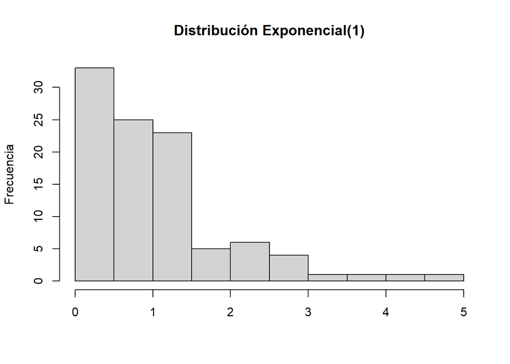

```r
#Poblaciones exponencial
set.seed(1)
hist(rexp(100,1),xlab="",ylab="Frecuencia",main="Distribución Exponencial(1)")
```

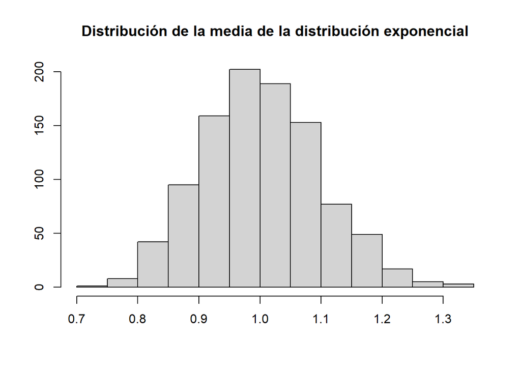

```r
Muestras1<-replicate(1000,mean(rexp(100,1)))
hist(Muestras1,xlab="",ylab="",main="Distribución de la media de la distribución exponencial")
```

Después de esta introducción con las siguietes fórmulas que ilustraremos mas adelante procederemos a realizar las estimaciones puntuales y por intervalos para la media de cada una de nuestras variables de interés, cabe aclarar que debido a nuestro tamaño de muestra general 202 y para cada grupo de 100 y 102, utilizaremos el TLC para hacer las aproximaciones a la distribución normal, también no contamos con la información de $\sigma$ por lo cuál por el mismo teorema estimaremos muestralmente esta y la procederemos a utilizar en los IC.

Estimaciones puntuales y por intervalos para la media, según todas nuestras variables cuantitativas. Para realizar las estimaciones para la media, varianza y proporción utilizaremos las siguientes formulas:

Intervalo para la media:
$$IC_{(\mu)}(1-\alpha)\%= \bar{x} \pm
Z_{\frac{\alpha}{2}}\frac{\sigma}{\sqrt{n}}$$

Intervalo para la diferencia de medias:
$$IC_{(\mu_{1}-\mu_{2})}(1-\alpha)\%=
(\bar{x}_{1}-\bar{x}_{2}) \pm
Z_{\frac{\alpha}{2}}\sqrt{\frac{\sigma_{1}^2}{{n_{1}}}+\frac{\sigma_{2}^2}{{n_{2}}}}$$
Intervalo de confianza para la proporción:
$$IC_{({p})}(1-\alpha)\%= \hat{p} \pm
Z_{\frac{\alpha}{2}}\sqrt{\frac{\hat{p}(1-\hat{p})}{{n}}}$$
Intervalo de confianza para la diferencia de proporciones:
$$IC_{(p_{1}-p_{2})}(1-\alpha)\%=
(\hat{p}_{1}-\hat{p}_{2}) \pm
Z_{\frac{\alpha}{2}}\sqrt{\frac{\hat{p}_{1}(1-\hat{p}_{1})}{{n_{1}}}+\frac{\hat{p}_{2}(1-\hat{p}_{2})}{{n_{2}}}}$$
Intervalo de confianza para la varianza:
$$IC_{(\sigma^2)}(1-\alpha)\%=[(n-1)\frac{S^2}{\chi_{n-1;\frac{\alpha}{2}}};(n-1)\frac{S^2}{\chi_{n-1;1-\frac{\alpha}{2}}}]$$

Empezaremos con el intervalo de confianza para la media:

```
##            LBM   BMI   SSF  Bfat
## 2.5%     63.07 22.56 64.53 12.65
## Promedio 64.87 22.96 69.02 13.51
## 97.5%    66.68 23.35 73.51 14.36
```

Cómo se observa en la tabla anterior el 2.5% hace referencia al límite inferior del IC con un 95% de confianza, así como el 97.5% el superior. Por lo cuál podemos concluir lo siguiente:

- El promedio de LBM se encontrará con un 95% de confianza entre 63.07 y 66.68 total de masa magra.
- El promedio de BMI se encontrará con un 95% de confianza entre 22.56 y 23.35 %.
- El promedio de SSF se encontrará con un 95% de confianza entre 64.53 y 73.51 % suma pliegues de piel.
- El promedio de Bfat se encontrará con un 95% de confianza entre 12.65 y 14.36 %. <> En general observamos que para las variables SSF, se presenta el IC con mayor longitud lo que nos indica que la desviación estándar de este es mas amplica en comparación con las demás.

Estimaciones puntuales y por intervalos para la varianza:

```r
ICVar<- function(x){
  c((length(x)-1)*var(x)/qchisq(1-0.025,length(x)-1),var(x),(length(x)-1)*var(x)/qchisq(0.025,length(x)-1))
}

U<-apply(Cuantitativas[,-1],2,ICVar)
rownames(U)<-c("2.5%","Varianza","97.5%");round(U,2)
```

```
##             LBM   BMI     SSF  Bfat
## 2.5%     141.80  6.81  880.26 31.80
## Varianza 170.83  8.20 1060.50 38.31
## 97.5%    209.84 10.08 1302.70 47.06
```

```r
ICVar<- function(x){
  c((length(x)-1)*var(x)/qchisq(1-0.025,length(x)-1),var(x),(length(x)-1)*var(x)/qchisq(0.025,length(x)-1))
}

Aux<-apply(Cuantitativas[,-1],2,ICVar)
rownames(U)<-c("2.5%","Varianza","97.5%");Aux<-Aux[-c(1,3),];sqrt(round(Aux,2))/202
```

```
##        LBM        BMI        SSF       Bfat
## 0.06470394 0.01417606 0.16121445 0.03064113
```

Nuetro interés radica en obsservar cada variable según el género, para poder notar a nivel individual el comportamiento de estas estimaciones. En la siguiente tabla podremos ilustrar estas estimaciones. Para esto generaremos tablas resumenes con las estimaciones puntuales para la media y varianza, junto con su intervalo de confianza del 95%.

**LBM**

```r
library(plyr)
ddply(Cuantitativas, "Sex",summarise,N=length(LBM),mean=mean(LBM),Var=var(LBM),Mu_2.5=IC(LBM)[1],Mu_97.5=IC(LBM)[2],Var_2.5=ICVar(LBM)[1],Var_97.5=ICVar(LBM)[2])
```

```
##      Sex   N     mean      Var   Mu_2.5  Mu_97.5  Var_2.5 Var_97.5
## 1 Female 100 54.89490 47.91675 53.53818 54.89490 36.93883 47.91675
## 2   Male 102 74.65686 97.75238 72.73814 74.65686 75.53950 97.75238
```

**BMI**

```r
ddply(Cuantitativas, "Sex",summarise,N=length(BMI),mean=mean(BMI),Var=var(LBM),Mu_2.5=IC(BMI)[1],Mu_97.5=IC(BMI)[2],Var_2.5=ICVar(BMI)[1],Var_97.5=ICVar(BMI)[2])
```

```
##      Sex   N     mean      Var   Mu_2.5  Mu_97.5  Var_2.5 Var_97.5
## 1 Female 100 21.98920 47.91675 21.47176 21.98920 5.372950 6.969747
## 2   Male 102 23.90363 97.75238 23.36656 23.90363 5.918555 7.658944
```

**SSF**

```r
ddply(Cuantitativas, "Sex",summarise,N=length(SSF),mean=mean(SSF),Var=var(SSF),Mu_2.5=IC(SSF)[1],Mu_97.5=IC(SSF)[2],Var_2.5=ICVar(SSF)[1],Var_97.5=ICVar(SSF)[2])
```

```
##      Sex   N     mean       Var   Mu_2.5  Mu_97.5  Var_2.5  Var_97.5
## 1 Female 100 86.97300 1145.8606 80.33841 86.97300 883.3394 1145.8606
## 2   Male 102 51.42255  355.4762 47.76363 51.42255 274.6991  355.4762
```

- Se observa promedio de SSF se encontrará para los hombres con un 95% de confianza entre 47.7 y 51.4 suma de pliegues en la piel y que para las mujeres se encontrará entre 80.3 y 86.97 con la misma confianza. Se observa que el IC de los hombres es menor lo cuál nos describe que referente a esta variable se espera que el suma de pliegues en la piel para los hombres sea inferior, lo que nos describe que esta población tiende a acumular menor cantidad de estos pliegues.
- Se observa que la varianza de SSF se encontrará para los hombres con con un 95% de confianza entre 274.6 y 355.47 total de masa magra mientras que para las mujeres se encontrará entre 883.33 y 1145.86 con la misma confianza. Se observa que el IC de las mujeres es mayor lo cuál nos describe que referente a esta variable se espera que exista mayor variabilidad.

**Bfat**

```r
ddply(Cuantitativas, "Sex",summarise,N=length(Bfat),mean=mean(Bfat),Var=var(Bfat),Mu_2.5=IC(Bfat)[1],Mu_97.5=IC(Bfat)[2],Var_2.5=ICVar(Bfat)[1],Var_97.5=ICVar(Bfat)[2])
```

```
##      Sex   N      mean      Var    Mu_2.5   Mu_97.5   Var_2.5 Var_97.5
## 1 Female 100 17.849100 29.73402 16.780353 17.849100 22.921836 29.73402
## 2   Male 102  9.250882 10.14227  8.632844  9.250882  7.837578 10.14227
```

Ahora realizaremos la estimación puntual para la proporción y su intervalo por cada género y además realizaremos un intervalo para la diferencia de proporciones.

## Estimación puntual y por intervalo para la proporción

```r
ICprop<- function(x,n){
  x+c(1,0,-1)*sqrt(((x*(1-x))/n))*qnorm(0.025)
}
IcpropD<- function(x,y,n1,n2){
  x-y+c(1,0,-1)*sqrt(((x*(1-x))/n1)+((y*(1-y))/n2))*qnorm(0.025)
}
P<-data.frame(rbind(round(ICprop(100/202,202),3),round(ICprop(102/202,202),3),round(IcpropD(100/202,102/202,202,202),3)))
rownames(P)<- c("Female","Male","Diferencia de proporciones");colnames(P)<- c("2.5%","P","97.5");P
```

```
##                              2.5%      P  97.5
## Female                      0.426  0.495 0.564
## Male                        0.436  0.505 0.574
## Diferencia de proporciones -0.107 -0.010 0.088
```

- Con un nivel de confianza del 95% se espera que la proporción de mujeres se encuentre entre 42.6% y 56.4%.
- Con un nivel de confianza del 95% se espera que la proporción de hombres se encuentre entre 43.6% y 57.4%.
- Con un nivel de confianza del 95% se espera que la diferente entre las proporciones de los géneros se encuentre entre -0.107 y 0.088, el 0 esta dentro del intervalo por lo cual concluimos que no existen diferencias significativas entre la proporción.